# konicek_homework_10

kelli

2025-04-03

# Libraries

```r
library(arm)
library(car)
library(here)
library(tidyverse)
library(ggeffects)
#install.packages('nlstools')
library(nlstools)
library(MuMIn)
library(GGally)
library(glmmTMB)
library(ggResidpanel)
library(gridExtra)
```

## Upload Data

```r
raw_wai <- read_csv(here("week_10", "data","AlaWai_DiscreteBottle.csv"))%>%
  select(SampleName,vvhA,Season,Site,SampleDepth,Rainfall_5Day,AirTemp,O2Conc,Salinity,WaterTemp,Turbidity,Chlorophyll,NOx,Silicate,POC,TotalP,"Tyrosine" = 'Tyrosine-like',HIX,"Humic" = 'VisibleHumic-like')%>%
  drop_na()

raw_wai$Site <- as.factor(raw_wai$Site)
```

# 1.

*Start by analyzing general spatial and temporal patterns of V. vulnificus abundance. Plot how abundance varies between sites, seasons, and depths.*

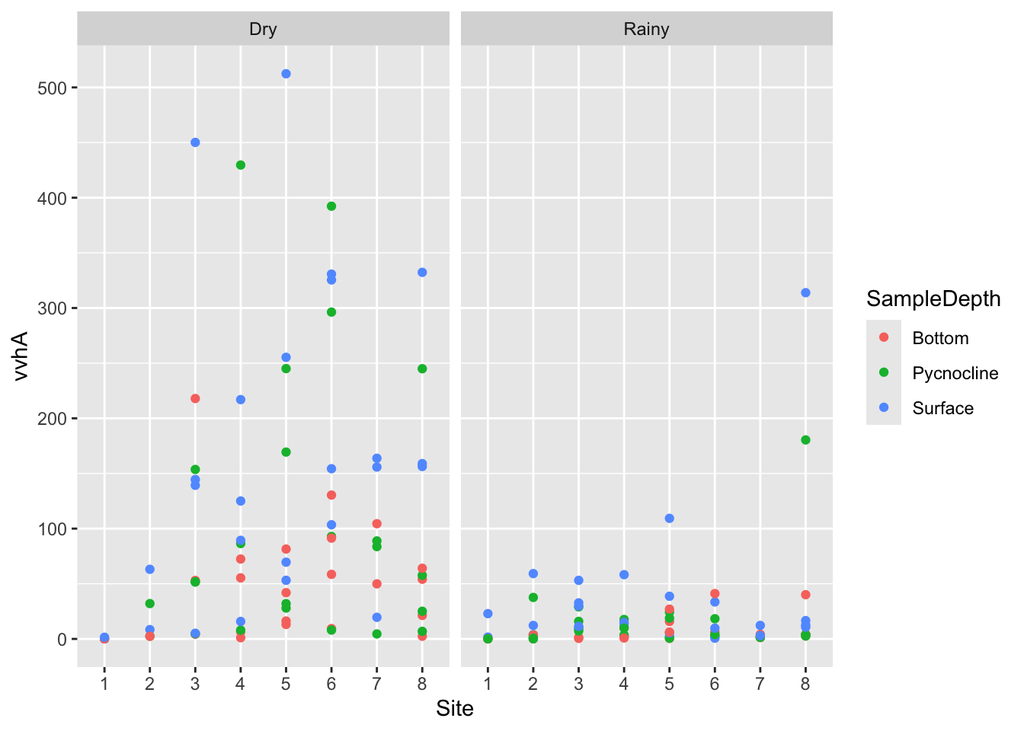

```r
#plot how abundance varies between site, season, sampledepth
ggplot(raw_wai, aes(Site, vvhA,color=SampleDepth)) + geom_point() +
facet_wrap(~Season)
```

OK these say to me that 1) the gene copy data is pretty varied by site, 2) It looks like gene copy tends to rise for sites during the dry season. 3) looks like it could be a lognormal distribution for the gene copies

*Construct an appropriate model that tests whether there are effects of these predictors, and interactions between them.*

```r
logmod <- lm(log10(vvhA)~Site*SampleDepth*Season, data=raw_wai)
Anova(logmod)
```

```
## Anova Table (Type II tests)
##
## Response: log10(vvhA)
##                         Sum Sq  Df F value    Pr(>F)
## Site                    38.691   7 14.5071 4.009e-13 ***
## SampleDepth             12.127   2 15.9143 9.041e-07 ***
## Season                  23.219   1 60.9408 4.423e-12 ***
## Site:SampleDepth         4.599  14  0.8621   0.60114
## Site:Season              6.557   7  2.4586   0.02238 *
## SampleDepth:Season       0.027   2  0.0353   0.96537
## Site:SampleDepth:Season  3.762  14  0.7053   0.76476
## Residuals               40.387 106
## ---
## Signif. codes:  0 '***' 0.001 '**' 0.01 '*' 0.05 '.' 0.1 ' ' 1
```

So it looks like Site, Sample Depth, and Season all have an effect. The only interaction that has an effect is the interaction between sites and the season.

*Figure out how the response variable (gene copies per mL) should be modeled (i.e., whether to transform or not, whether to use a non-normal distribution).*

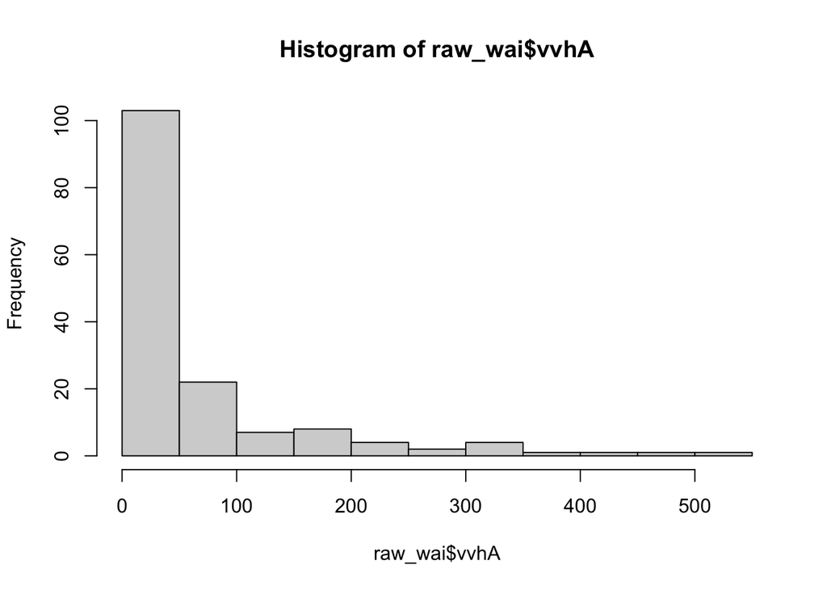

```r
#look at distribution of data: looks like lognormal distribution to me?
hist(raw_wai$vvhA)
```

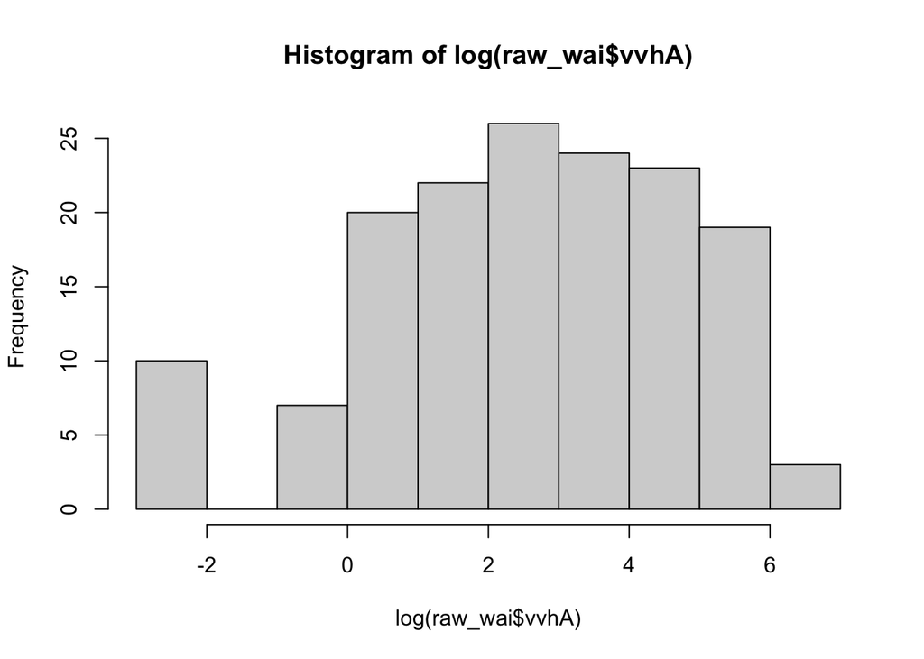

```r
hist(log(raw_wai$vvhA))
```

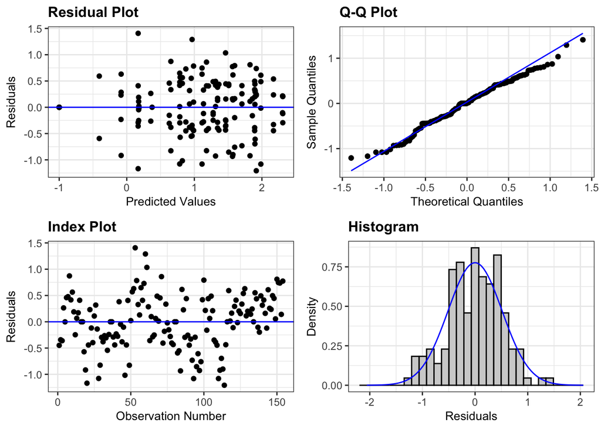

```r
resid_panel(logmod)
```

I also tried a gamma distribution, but I think the residuals for the lognormal distribution look a little better, particularly for the Q-Q plot.

*What are the magnitudes of the modeled effects?*

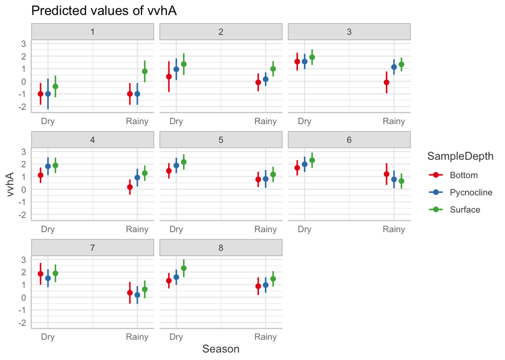

```r
plot(ggeffect(logmod, terms= c("Season","SampleDepth","Site")))
```

```r
summary(logmod)
```

```
##
## Call:
## lm(formula = log10(vvhA) ~ Site * SampleDepth * Season, data = raw_wai)
##
## Residuals:
##      Min       1Q   Median       3Q      Max
## -1.20730 -0.34636  0.00625  0.40719  1.40711
##
## Coefficients:
##                                           Estimate Std. Error t value Pr(>|t|)
## (Intercept)                             -1.000e+00  4.365e-01  -2.291 0.023935
## Site2                                    1.375e+00  7.560e-01   1.819 0.071787
## Site3                                    2.565e+00  5.635e-01   4.551 1.43e-05
## Site4                                    2.114e+00  5.346e-01   3.954 0.000139
## Site5                                    2.465e+00  5.346e-01   4.612 1.12e-05
## Site6                                    2.704e+00  5.346e-01   5.058 1.79e-06
## Site7                                    2.859e+00  6.173e-01   4.631 1.04e-05
## Site8                                    2.314e+00  5.346e-01   4.328 3.42e-05
## SampleDepthPycnocline                   -9.800e-15  7.560e-01   0.000 1.000000
## SampleDepthSurface                       5.930e-01  6.173e-01   0.961 0.338892
## SeasonRainy                             -3.634e-15  6.173e-01   0.000 1.000000
## Site2:SampleDepthPycnocline              5.790e-01  1.069e+00   0.542 0.589257
## Site3:SampleDepthPycnocline              6.615e-03  8.909e-01   0.007 0.994090
## Site4:SampleDepthPycnocline              7.102e-01  8.909e-01   0.797 0.427124
## Site5:SampleDepthPycnocline              4.270e-01  8.729e-01   0.489 0.625723
## Site6:SampleDepthPycnocline              2.802e-01  8.729e-01   0.321 0.748830
## Site7:SampleDepthPycnocline             -3.498e-01  9.429e-01  -0.371 0.711404
## Site8:SampleDepthPycnocline              2.830e-01  8.729e-01   0.324 0.746455
## Site2:SampleDepthSurface                 3.957e-01  9.760e-01   0.405 0.685966
## Site3:SampleDepthSurface                -2.410e-01  7.767e-01  -0.310 0.756981
## Site4:SampleDepthSurface                 1.895e-01  7.560e-01   0.251 0.802545
## Site5:SampleDepthSurface                 1.127e-01  7.560e-01   0.149 0.881806
## Site6:SampleDepthSurface                 1.189e-02  7.560e-01   0.016 0.987482
## Site7:SampleDepthSurface                -5.520e-01  8.358e-01  -0.660 0.510412
## Site8:SampleDepthSurface                 3.990e-01  7.767e-01   0.514 0.608481
## Site2:SeasonRainy                       -4.583e-01  9.429e-01  -0.486 0.627937
## Site3:SeasonRainy                       -1.650e+00  8.358e-01  -1.974 0.050967
## Site4:SeasonRainy                       -9.380e-01  7.560e-01  -1.241 0.217412
## Site5:SeasonRainy                       -6.822e-01  7.560e-01  -0.902 0.368879
## Site6:SeasonRainy                       -4.957e-01  8.166e-01  -0.607 0.545148
```

[output cut: 58 more lines]

```
## Site7:SampleDepthPycnocline:SeasonRainy
## Site8:SampleDepthPycnocline:SeasonRainy
## Site2:SampleDepthSurface:SeasonRainy
## Site3:SampleDepthSurface:SeasonRainy
## Site4:SampleDepthSurface:SeasonRainy
## Site5:SampleDepthSurface:SeasonRainy
## Site6:SampleDepthSurface:SeasonRainy    *
## Site7:SampleDepthSurface:SeasonRainy
## Site8:SampleDepthSurface:SeasonRainy
## ---
## Signif. codes:  0 '***' 0.001 '**' 0.01 '*' 0.05 '.' 0.1 ' ' 1
##
## Residual standard error: 0.6173 on 106 degrees of freedom
## Multiple R-squared:  0.6994, Adjusted R-squared:  0.5661
## F-statistic: 5.247 on 47 and 106 DF,  p-value: 7.932e-13
```

*What are your interpretations of the results so far?*

Weeeelll it looks like there might be more V. vulnificus when it is drier, but how much that varies has to do with the site. Sample Depth is maybe less important than site and season. It might be that increased salinity or a higher concentration of DOM from runoff encourages V.vulnificus when there is less water flowing into the system to diluate stuff.

# 2.

*Use scatterplots of V. vulnificus concentration vs. the predictors to consider which should be transformed for use in a linear model / generalized linear model.*

```r
# Get the names of the columns in the dataset (excluding 'vvhA')
wai <- raw_wai %>%
  select(vvhA,Rainfall_5Day, AirTemp, O2Conc, Salinity,WaterTemp, Turbidity, Chlorophyll, NOx, Silicate, POC, TotalP, Tyrosine, HIX,Humic)

column_names <- setdiff(names(wai), "vvhA")

# Loop over each column and create scatter plots
for (col_name in column_names) {
  # Create the scatter plot comparing vvhA to the current column
  plot <- ggplot(wai, aes_string(x = col_name, y = "vvhA")) +
    geom_point() +
    geom_smooth()+
    labs(x = col_name,
         y = "vvhA")

plot
}
```

```r
par(mfrow = c(4,4), mar= c(3,3,2,1))
for (col_name in column_names) {
  # Create the scatter plot comparing vvhA to the current column

    wai$log_vvhA <- log10(wai$vvhA)  # Log-transform vvhA
  wai$log_col <- log10(wai[[col_name]])  # Log-transform the current column


  plot2 <- ggplot(wai, aes_string(x = wai$log_col, y = wai$log_vvhA)) +
    geom_point() +
    geom_smooth()+
    labs(x = col_name,
         y = "vvhA")+
    theme_light()

 plot2
}
```

To transform: Maybe: NOx, Silicate,POC, and Humic?

*Start by making single-predictor models for each of the 14 predictors listed above.*

WaterTemp, Turbidity, Chlorophyll, NOx, Silicate, POC, TotalP, Tyrosine.like, HIX, and VisibleHumic.like.

```r
logmod0 <-lm(log10(vvhA) ~ 1, data= wai)
logmod1 <- lm(log10(vvhA) ~ Rainfall_5Day, data= wai)
logmod2 <- lm(log10(vvhA) ~ AirTemp, data= wai)
logmod3<- lm(log10(vvhA) ~ O2Conc, data= wai)
logmod4<- lm(log10(vvhA) ~ Salinity, data= wai)
logmod5<- lm(log10(vvhA) ~ WaterTemp, data= wai)
logmod6<- lm(log10(vvhA) ~ Turbidity, data= wai)
logmod7<- lm(log10(vvhA) ~ Chlorophyll, data= wai)
logmod8<- lm(log10(vvhA) ~ log(NOx), data= wai)
logmod9<- lm(log10(vvhA) ~ log(Silicate), data= wai)
logmod10<- lm(log10(vvhA) ~ log(POC), data= wai)
logmod11<- lm(log10(vvhA) ~ TotalP, data= wai)
logmod12<- lm(log10(vvhA) ~ Tyrosine, data= wai)
logmod13<- lm(log10(vvhA) ~ HIX, data= wai)
logmod14<- lm(log10(vvhA) ~ log(Humic), data= wai)
```

*If you make an AIC table of the 14 models, what do the Akaike weights look like?*

```r
all <- list(logmod0,logmod1,logmod2,logmod3,logmod4,logmod5,logmod6,logmod7,logmod8,logmod9,logmod10,logmod11,logmod12,logmod13,logmod14)

aic.table = model.sel(all)
aic.table
```

```
## Model selection table
##      (Int) Rnf_5Dy    ArT      O2C      Sln    WtT    Trb      Chl log(NOx)
## 10 -0.7280
## 15  2.8580
## 9   0.6315                                                           0.4008
## 11 -1.1470
## 5   3.4030                         -0.07975
## 2   0.8310 0.05084
## 3  -3.6330         0.1819
## 12  0.4506
## 13  0.4511
## 6  -4.1240                                  0.1938
## 7   0.7772                                         0.1039
## 14  0.7273
## 1   1.1100
```

[output cut: 35 more lines]

*Which predictors, on their own, best explain V. vulnificus concentration?*

It looks like silicate is da best babyeeeeee?

```r
sw(all)
```

```
##                      log(Silicate) log(Humic) log(NOx) log(POC) Salinity
## Sum of weights:          1         <0.01      <0.01    <0.01    <0.01
## N containing models:     1             1          1        1        1
##                      Rainfall_5Day AirTemp TotalP Tyrosine WaterTemp Turbidity
## Sum of weights:      <0.01         <0.01   <0.01  <0.01    <0.01     <0.01
## N containing models:     1             1       1      1        1         1
##                      HIX   O2Conc Chlorophyll
## Sum of weights:      <0.01 <0.01  <0.01
## N containing models:     1     1      1
```

*What does this mean?*

OK. well, if I don’t transform any of the predictors, humic DOC has the highest AICc. If I transform the predictors that look like they have a linear relationship after transforming, silicate has the lowest AICc and an AICc weight of 1. That essentially means that that model, on its own, is the best fitting by far out of all the options.

*What is the downside of using only single-predictor models in this context?* Especially for this data, it’s pretty likely that there are interactions between these predictors that might explain driving forces more than one predictor alone. For instance, both silicate and DOM might have some sort of interaction that explains why those two things are so important. Maybe they are both products of runoff, though I am not sure what the difference between what HIX is measureing and visible humic DOM is.

*Now make one big model that contains all 14 predictors.*

```r
Bigmod <-lm(log10(vvhA) ~ Rainfall_5Day+AirTemp+O2Conc+Salinity+WaterTemp+Turbidity+Chlorophyll+log(NOx)+log(Silicate)+log(POC)+TotalP+Tyrosine+HIX+log(Humic), na.action = na.pass, data= wai)
```

*Do marginal null hypothesis tests on the predictors.*

```r
Anova(Bigmod)
```

```
## Anova Table (Type II tests)
##
## Response: log10(vvhA)
##                Sum Sq  Df F value    Pr(>F)
## Rainfall_5Day  5.7603   1 25.9701 1.111e-06 ***
## AirTemp        3.8922   1 17.5479 4.951e-05 ***
## O2Conc         0.1435   1  0.6470   0.42254
## Salinity       0.0002   1  0.0009   0.97626
## WaterTemp      0.8809   1  3.9715   0.04823 *
## Turbidity      0.0164   1  0.0741   0.78585
## Chlorophyll    0.5106   1  2.3019   0.13149
## log(NOx)       0.0746   1  0.3365   0.56278
## log(Silicate)  1.2689   1  5.7210   0.01810 *
## log(POC)       0.0014   1  0.0063   0.93684
## TotalP         0.0001   1  0.0004   0.98414
## Tyrosine       0.9588   1  4.3228   0.03944 *
## HIX            5.7131   1 25.7574 1.219e-06 ***
## log(Humic)     4.0835   1 18.4102 3.316e-05 ***
## Residuals     30.8308 139
## ---
## Signif. codes:  0 '***' 0.001 '**' 0.01 '*' 0.05 '.' 0.1 ' ' 1
```

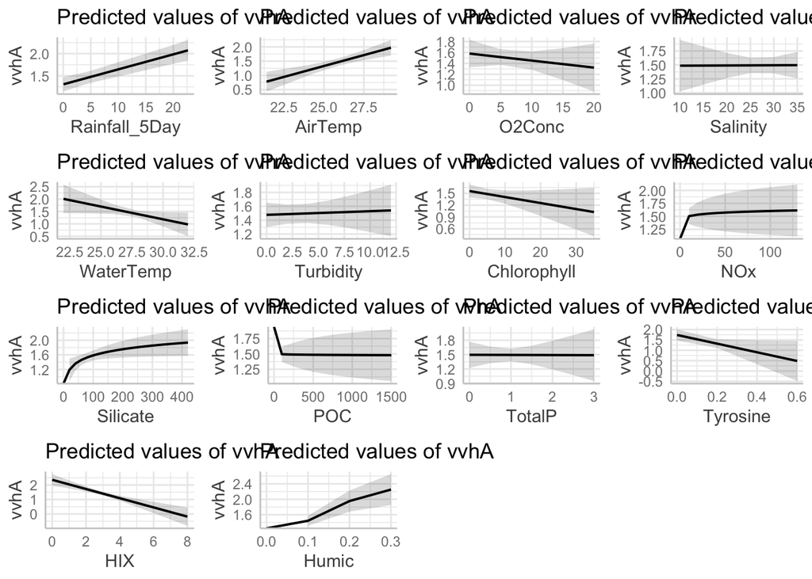

```r
grid.arrange(grobs = plot(ggeffect(Bigmod)))
```

*Which seem important for explaining V. vulnificus?*

Kay well when all the predictors are combined, Humic DOM, Silicate, Rainfall and air/watertemperature seems important. Rainfall is going a different way than I thought it would, though, where the more rain falls the more V. vulnificus concentration goes up. LTR also shoes Tyrosine might be important, but it has an inverse relationship to V.vlnificus concentration

*Collectively, how much variation in V. vulnificus concentration can be explained?*

```r
summary(Bigmod)
```

```
##
## Call:
## lm(formula = log10(vvhA) ~ Rainfall_5Day + AirTemp + O2Conc +
##     Salinity + WaterTemp + Turbidity + Chlorophyll + log(NOx) +
##     log(Silicate) + log(POC) + TotalP + Tyrosine + HIX + log(Humic),
##     data = wai, na.action = na.pass)
##
## Residuals:
##      Min       1Q   Median       3Q      Max
## -1.24318 -0.33101  0.01351  0.35129  1.08012
##
## Coefficients:
##                 Estimate Std. Error t value Pr(>|t|)
## (Intercept)    1.8880359  1.2186648   1.549   0.1236
## Rainfall_5Day  0.0338659  0.0066455   5.096 1.11e-06 ***
## AirTemp        0.1529184  0.0365045   4.189 4.95e-05 ***
## O2Conc        -0.0128470  0.0159711  -0.804   0.4225
## Salinity       0.0003906  0.0131055   0.030   0.9763
## WaterTemp     -0.1032057  0.0517875  -1.993   0.0482 *
## Turbidity      0.0053154  0.0195255   0.272   0.7859
## Chlorophyll   -0.0152489  0.0100508  -1.517   0.1315
## log(NOx)       0.0427292  0.0736576   0.580   0.5628
## log(Silicate)  0.2446933  0.1023029   2.392   0.0181 *
## log(POC)      -0.0057163  0.0720033  -0.079   0.9368
## TotalP        -0.0025545  0.1282897  -0.020   0.9841
## Tyrosine      -2.0890422  1.0047658  -2.079   0.0394 *
## HIX           -0.3178285  0.0626242  -5.075 1.22e-06 ***
## log(Humic)     0.7348743  0.1712708   4.291 3.32e-05 ***
## ---
## Signif. codes:  0 '***' 0.001 '**' 0.01 '*' 0.05 '.' 0.1 ' ' 1
##
## Residual standard error: 0.471 on 139 degrees of freedom
## Multiple R-squared:  0.7705, Adjusted R-squared:  0.7474
## F-statistic: 33.34 on 14 and 139 DF,  p-value: < 2.2e-16
```

about 75% of the variation can be explained in this model, cuz we are looking at the R squared value.

*What is a potential downside of this approach to inference (i.e., one big model with marginal tests)?*

A potential downside is that this many predictors can reduce the confidence for all the predictors, especially if there’s not that many data points. Is it a tragedy of the commons maybe if the resource was confidence in the influence of a predictor.

*Now construct all possible models containing these 14 predictors (you can ignore interactions…and recall that there is an R function that automates this process).*

```r
options(max.print = 100)  # Only print the first 100 elements
dredge <- dredge(Bigmod, extra = "R^2")
model.sel(dredge)
```

```
## Global model call: lm(formula = log10(vvhA) ~ Rainfall_5Day + AirTemp + O2Conc +
##     Salinity + WaterTemp + Turbidity + Chlorophyll + log(NOx) +
##     log(Silicate) + log(POC) + TotalP + Tyrosine + HIX + log(Humic),
##     data = wai, na.action = na.pass)
## ---
## Model selection table
##            (Int)     ArT        Chl        HIX   log(Hmc)   log(NOx)   log(POC)
## 12624  1.450e+00 0.14390 -1.813e-02 -0.3031000  7.198e-01
## 12752  1.503e+00 0.14800 -1.588e-02 -0.3047000  6.994e-01
## 12640  1.822e+00 0.14790 -1.797e-02 -0.3166000  7.570e-01  3.789e-02
## 14672  1.382e+00 0.14330 -1.784e-02 -0.2998000  7.043e-01
##         log(Slc)        O2C Rnf_5Dy        Sln        TtP        Trb        Tyr
## 12624  0.2734000            0.03562                                  -2.2130000
## 12752  0.2848000 -1.330e-02 0.03527                                  -2.1130000
## 12640  0.2339000            0.03420                                  -2.2000000
## 14672  0.2788000            0.03564                        7.115e-03 -2.2180000
##              WtT      R^2 df   logLik  AICc  delta weight
## 12624 -8.558e-02 0.768600 10  -95.322 212.2   0.00  0.075
## 12752 -9.221e-02 0.769800 11  -94.908 213.7   1.49  0.036
## 12640 -9.455e-02 0.769000 11  -95.159 214.2   1.99  0.028
## 14672 -8.583e-02 0.768800 11  -95.243 214.3   2.16  0.026
##  [ reached getOption("max.print") -- omitted 16380 rows ]
## Models ranked by AICc(x)
```

*Which predictors consistently occur in the most-supported models?*

Oh fun! Airtemp, Chlorophyll, Rainfall, HIX, Humic DOM, Silicate, Tyrosine, Watertemp.

*What are the sums of Akaike weights for each predictor?*

```r
sw(dredge)
```

```
##                      Rainfall_5Day HIX  log(Humic) AirTemp log(Silicate)
## Sum of weights:      1.00          1.00 1.00       1.00    0.98
## N containing models: 8192          8192 8192       8192    8192
##                      WaterTemp Tyrosine Chlorophyll O2Conc log(NOx) Salinity
## Sum of weights:      0.84      0.83     0.69        0.36   0.29     0.27
## N containing models: 8192      8192     8192        8192   8192     8192
##                      TotalP log(POC) Turbidity
## Sum of weights:      0.26   0.26     0.25
## N containing models: 8192   8192     8192
```

*Plot the fitted relationships from the best model.*

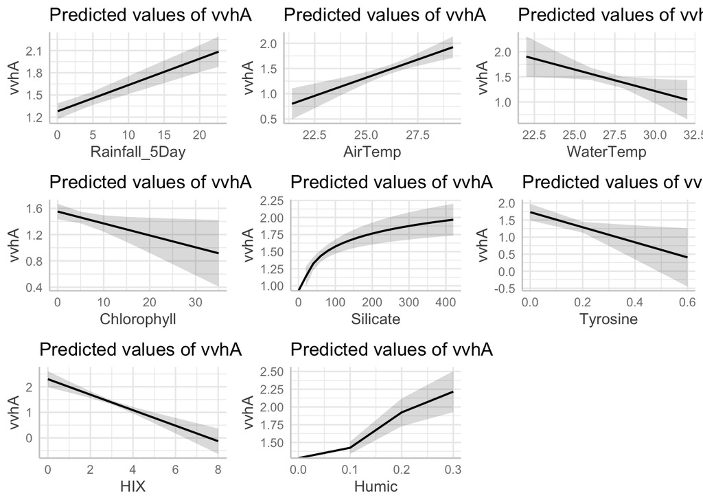

```r
bestmod <- lm(log10(vvhA) ~ Rainfall_5Day+AirTemp+WaterTemp+Chlorophyll+log(Silicate)+Tyrosine+HIX+log(Humic), na.action = na.pass, data= wai)
grid.arrange(grobs = plot(ggeffect(bestmod)))
```

*How do these results compare to the other approaches?* This is similar to the all predictor approach, except Chlorophyll is in here too! We got to see a predictor that had a little more impact once we took out some of the noise. That is so cool.

I might also guess that runoff has a positive impact on vvhA concentration. This is because silicate and visible Humic are positively correlated with vvhA concentration, and those are typical runoff byproducts. I am not quite sure how HIX is measured based on my, like, five second google searh, so if the lower the HIX score the higher the visible humic, then I might be in business there.

Finally, I might guess that plants or algae in the water can keep vvhA concentration down. This is because chlorophyll and tyrosine are negatively correlated with vvhA, and I think you’d measure Tyrosine as an amino acid for plant stuff/plant products.